# Tidy Tuesday Homework 1: Week of Oct. 28th

Diana Gao

2024-11-05

Goal of this analysis was to compare the popularity of horror monster movies with their rating. I wanted to see if more popular movies tend to be more highly rated (which is what I would think, if it’s bad why would people see it?)

# Setup

#### Load the Libraries

```r
library(tidytuesdayR)
library(tidyverse)
library(here)
```

#### Load in Data

This week I will be using the “monster movie” dataset from TidyTuesday, week of Oct. 28th.

```r
tuesdata <- tidytuesdayR::tt_load('2024-10-29')
monster_movie_genres <- tuesdata$monster_movie_genres
monster_movies <- tuesdata$monster_movies
```

#### Functions

This dataset has some outliers - namely a few super duper popular movies that I want to cut out. But I don’t want to do this arbitrarily - so I will make a function.

First: a function to detect outliers. This is done by splitting the data into quantiles (I chose 4 quartiles), and detecting any data points which fall outside of these quartiles.

```r
detect_outlier <- function(x) {
  Quantile1 <- quantile(x, probs=.25) # calc first quantile limit
  Quantile3 <- quantile(x, probs=.75) # calc third quantile limit
  IQR = Quantile3 - Quantile1 # calculate interquartile range
  x > Quantile3 + (IQR * 1.5) | x < Quantile1 - (IQR * 1.5) # return true if x is outside of the quartiles by .5x of the IQR
}
```

This function is not used directly, but will be called upon by the second function…

Which removes outliers – This function can work for removing outliers pulling from multiple columns, though in this dataset I am planning to just do it for one. It will say which cols were removed from the data as well.

```r
remove_outlier <- function(dataframe, columns = names(dataframe)) {
  for (col in columns) { # for loop to traverse in columns vector
    dataframe <- dataframe[!detect_outlier(dataframe[[col]]), ]   # remove observation if it satisfies detect_outlier function
  }
  print("Remove outliers") # shows all kept data, can check which ones were removed
  print(dataframe) # return dataframe
}
```

# Cleaning the data

Now, to clean up the data so it only holds info relevant to our plot :)

#### Trimming og dataframes

First up, looking at the data, monster_movies has the column “titletypes” which shows what kind of media the piece is (movie, video, or tvmovie). I will clean this up so that it only has movies in it.

```r
cleaned_movie_names <- monster_movies %>%
  filter(title_type == "movie", na.rm = TRUE)
```

Next, the monster_movie_genres data contains info of each movie’s listed genres on IMDb. I want to only select movies with “horror” as a listed genre.

```r
cleaned_horror_movies <- monster_movie_genres %>%
  filter(genres == "Horror", na.rm = TRUE)
```

#### Combining then Editing

Then, inner join the two tables so that the final dataframe has only monster MOVIES with the HORROR genre tag, and only keep relevant data. I will also clean out the outliers (movies with a huge amount of votes) and bin the movies into “old” (pre-2010), and “new” (post-2010) movies.

```r
horror_movies <- cleaned_movie_names %>%
  inner_join(cleaned_horror_movies, by = "tconst") %>% # merge two tables so only movies with horror as a genre are kept
  select(primary_title, average_rating, year, num_votes) %>% # keep only relevant columns
  remove_outlier(columns = "num_votes") %>% # remove outliers from dataset - seems like mostly the super popular ones (>~5k votes)
  mutate(year_bin = if_else(year > 2010, "new", "old")) # when data is evenly split along year, median year 2012 is cut in to the two diff bins. Set bins so movies released before 2010 are old and 2011 or later is new
```

```
## [1] "Remove outliers"
## # A tibble: 152 × 4
##    primary_title            average_rating  year num_votes
##    <chr>                             <dbl> <dbl>     <dbl>
##  1 The Monster                         6.2  1925      1412
##  2 The Monster Walks                   4.1  1932      1120
##  3 The Human Monster                   5.7  1939      1579
##  4 Man Made Monster                    6.1  1941      1953
##  5 The Monster and the Girl            6    1941       799
##  6 The Mad Monster                     3.5  1942      1969
##  7 The Undying Monster                 6.1  1942      1588
##  8 The Lady and the Monster            5.7  1944       504
##  9 The Monster Maker                   4.8  1944      1285
## 10 The Soul of a Monster               4.9  1944       289
## # ℹ 142 more rows
```

# Plotting

Plot this data! Number of votes on the x-axis, average rating on the y axis. I will separate new and old movies to see if there are different trends.

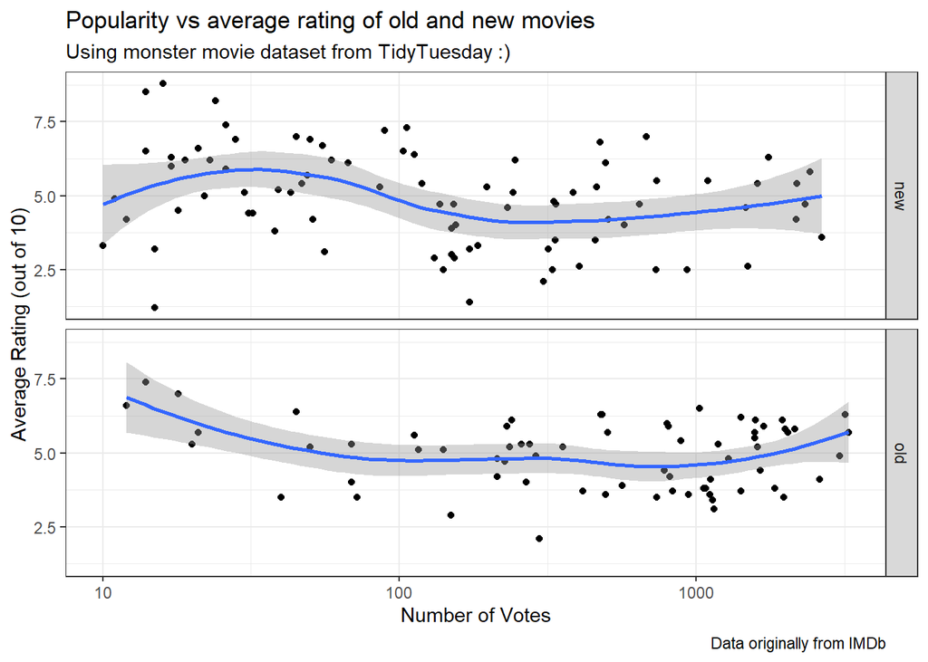

```r
ggplot(horror_movies, aes(x = num_votes, y = average_rating)) +
  geom_point() +
  scale_x_continuous(trans="log10") + # there are a lot of movies with <50 ratings, so log transform the x axis to make the data more readable
  geom_smooth() + # add trend line
  facet_grid(rows = vars(year_bin)) + # make separate plots for new and old movies
  labs(title = "Popularity vs average rating of old and new movies",
       subtitle = "Using monster movie dataset from TidyTuesday :)",
       caption = "Data originally from IMDb",
       x = "Number of Votes",
       y = "Average Rating (out of 10)") +
  theme_bw()
```